# JEWELS - Bayerische Staatsoper

[figure not shown]

[Bayerisches Staatsballett](https://www.staatsoper.de/staatsballett)

## GESCHENK-ABOS

Ab sofort sind unsere Geschenk-Abos buchbar!

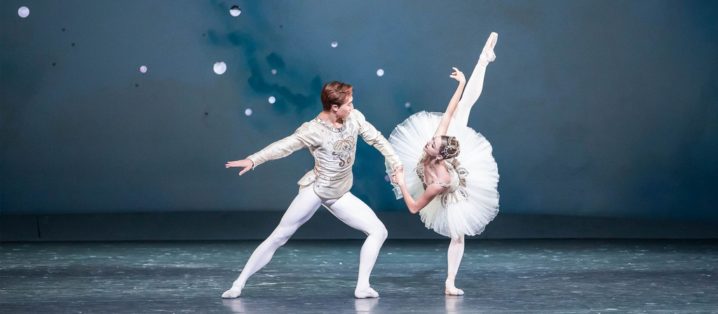

# JEWELS

empfohlen ab 10 Jahren  
Dreiteiliger Ballettabend  
Choreography by George Balanchine © The George Balanchine Trust

Choreographie George Balanchine. Musik Gabriel Fauré / Igor Strawinsky / Pjotr I. Tschaikowski.

Premiere am 27. Oktober 2018

Freitag, 22. Oktober 2021, 19.30 Uhr – 22.00 Uhr, Nationaltheater.

**Dauer** ca. 2 Stunden 30 Minuten

**Emeralds** (ca. 19.30 - 20.05 Uhr) Pause (ca. 20.05 - 20.25 Uhr) **Rubies** (ca. 20.25 - 20.50 Uhr) Pause (ca. 20.50 - 21.20 Uhr) **Diamonds** (ca. 21.20 - 21.55 Uhr)

[Termin merken](https://www.staatsoper.de/stuecke/jewels/2021-10-22-1930-12640/calendar.ics)

#BSBjewels

### supported by

[figure not shown]

| Musikalische Leitung | [Robert Reimer](https://www.staatsoper.de/biographien/reimer-robert) |
| --- | --- |
| Choreographie | [George Balanchine](https://www.staatsoper.de/biographien/balanchine-george) |
| Bühne | [Peter Harvey](https://www.staatsoper.de/biographien/harvey-peter) |
| Kostüme | [Karinska](https://www.staatsoper.de/biographien/karinska) |
| Licht | [Mark Stanley](https://www.staatsoper.de/biographien/stanley-mark) |

## EMERALDS

[output not shown]

## RUBIES

| Pianist | [Dmitry Mayboroda](https://www.staatsoper.de/biographien/mayboroda-dmitry) |
| --- | --- |
| Solo Paar | [Sofia Ivanova-Skoblikova](https://www.staatsoper.de/biographien/ivanova-skoblikova-sofia) [Osiel Gouneo](https://www.staatsoper.de/biographien/gouneo-osiel) |
| Solistin | [Prisca Zeisel](https://www.staatsoper.de/biographien/zeisel-prisca) |

## DIAMONDS

[output not shown]

| Ensemble des Bayerischen Staatsballetts |
| --- |
| Bayerisches Staatsorchester |

[Download Besetzungszettel (PDF)](https://www.staatsoper.de/media/content/PDF/Besetzungszettel_21_22/BSB_2122_JEWELS__BZ__2021_10_22__I.pdf)

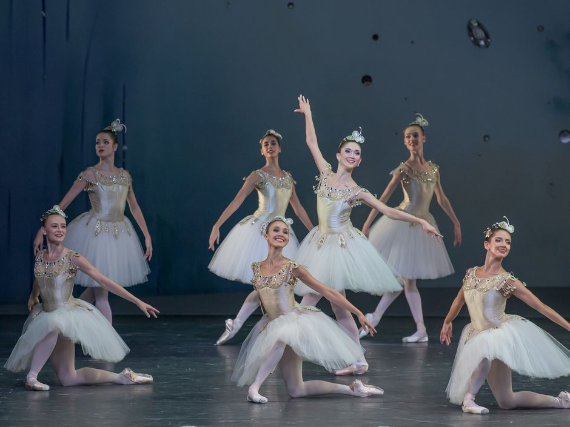

JEWELS: DIAMONDS - Ensemble

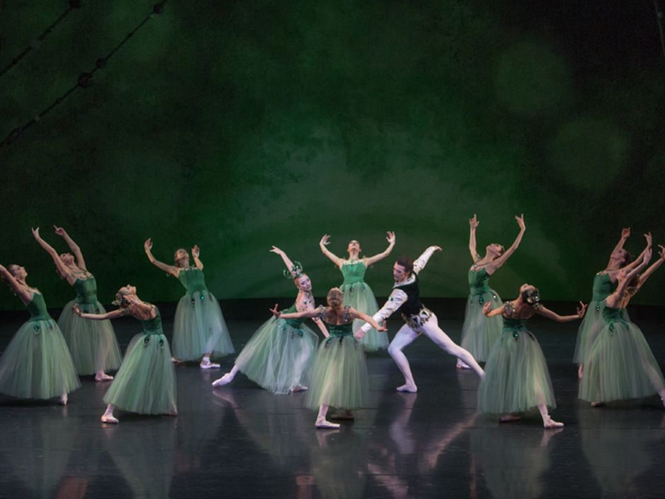

JEWELS: EMERALDS - Ensemble

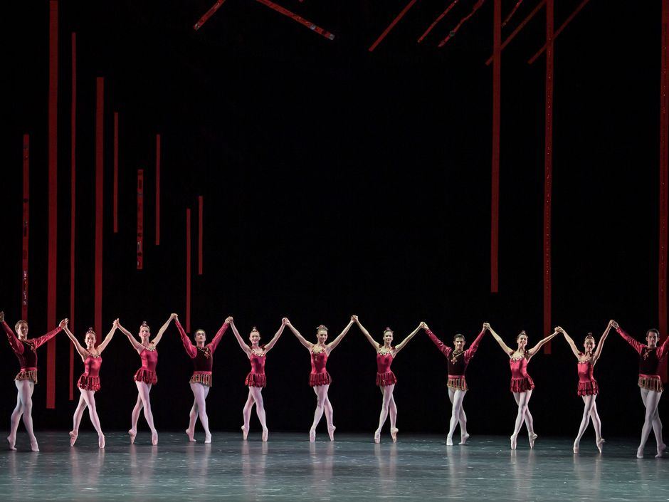

JEWELS: RUBIES, Ensemble

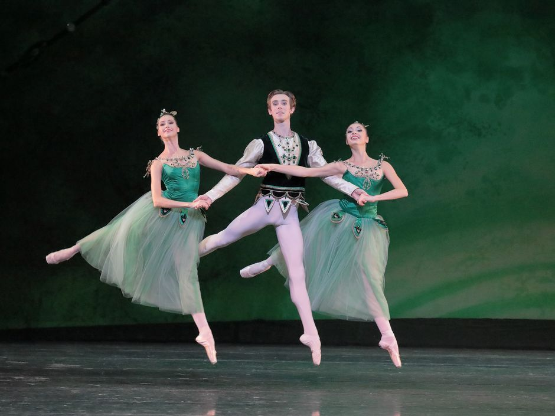

JEWELS: EMERALDS - Vera Segova, Dmitrii Vyskubenko, Maria Chiara Bono

## weitere Vorstellungen

Fr 24.02.23

## JEWELS

George Balanchine  
20.00 Uhr, Nationaltheater  
Abo-Ballett-Geschenk-Abo 176, <30

Preise H , € 88 / 77 / 63 / 50 / 35 / 23 / 11 / 8

Ballett

[Tickets](https://www.staatsoper.de/kartenanfrage?tx_sfstaatsoper_cardorderlist%5Bactivity%5D=13308&tx_sfstaatsoper_cardorderlist%5Bcontroller%5D=CardOrder&cHash=d6061dff0b81b0bfc41261f15eb405fd)

[VVK-Termin merken](https://www.staatsoper.de/stuecke/jewels/2023-02-24-2000-13308/calendar.ics)

So 26.02.23

## JEWELS

George Balanchine  
18.00 Uhr, Nationaltheater  
Familienvorstellung

Preise H , € 88 / 77 / 63 / 50 / 35 / 23 / 11 / 8

Ballett

[Tickets](https://www.staatsoper.de/kartenanfrage?tx_sfstaatsoper_cardorderlist%5Bactivity%5D=13311&tx_sfstaatsoper_cardorderlist%5Bcontroller%5D=CardOrder&cHash=4e14a5b19b09168399bbe648f083b248)

[VVK-Termin merken](https://www.staatsoper.de/stuecke/jewels/2023-02-26-1800-13311/calendar.ics)

Di 28.02.23

## JEWELS

George Balanchine  
19.30 Uhr, Nationaltheater  
Abo-Serie 11

Preise H , € 88 / 77 / 63 / 50 / 35 / 23 / 11 / 8

Ballett

[Tickets](https://www.staatsoper.de/kartenanfrage?tx_sfstaatsoper_cardorderlist%5Bactivity%5D=13312&tx_sfstaatsoper_cardorderlist%5Bcontroller%5D=CardOrder&cHash=73bfce5a82c3f2ed6018671cf3a67baa)

[VVK-Termin merken](https://www.staatsoper.de/stuecke/jewels/2023-02-28-1930-13312/calendar.ics)

Fr 03.03.23

## JEWELS

George Balanchine  
19.30 Uhr, Nationaltheater  
Abo-Serie 16

Preise H , € 88 / 77 / 63 / 50 / 35 / 23 / 11 / 8

Ballett

[Tickets](https://www.staatsoper.de/kartenanfrage?tx_sfstaatsoper_cardorderlist%5Bactivity%5D=13314&tx_sfstaatsoper_cardorderlist%5Bcontroller%5D=CardOrder&cHash=22d41ffc71c0f01a63e80f26a04177e1)

[VVK-Termin merken](https://www.staatsoper.de/stuecke/jewels/2023-03-03-1930-13314/calendar.ics)

Jewels (Plakat)

[figure not shown]

Jewels (Programm)

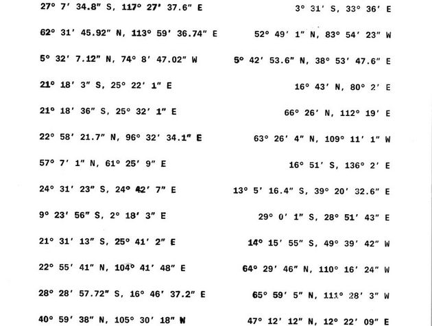

Jewels A1 (Plakat)

[figure not shown]

Trailer - JEWELS

00:00

01:22

[video not shown]

Videomagazin - Dancing JEWELS

00:00

05:05

[video not shown]

## Vergangene Vorstellungen

Di 29.03.22

## JEWELS

George Balanchine  
19.30 Uhr, Nationaltheater

Ballett

So 28.11.21

## JEWELS

George Balanchine  
18.00 Uhr, Nationaltheater

Ballett

Sa 27.11.21

## JEWELS

George Balanchine  
19.30 Uhr, Nationaltheater

Ballett

So 07.11.21

## JEWELS

George Balanchine  
19.30 Uhr, Nationaltheater

Ballett

Fr 22.10.21

## JEWELS

George Balanchine  
19.30 Uhr, Nationaltheater

Ballett

Sa 16.10.21

## JEWELS

George Balanchine  
19.30 Uhr, Nationaltheater

Ballett

Sa 09.10.21

## JEWELS

George Balanchine  
19.30 Uhr, Nationaltheater

Ballett

So 03.10.21

## JEWELS

George Balanchine  
18.00 Uhr, Nationaltheater

Ballett

Di 20.04.21

## STAATSOPER.TV: JEWELS

George Balanchine  
19.30 Uhr, *

Ballett

Mo 23.11.20

## Abgesagt: JEWELS

George Balanchine  
19.30 Uhr, Nationaltheater

Ballett

Sa 21.11.20

## Abgesagt: JEWELS

George Balanchine  
19.30 Uhr, Nationaltheater

Ballett

Di 10.11.20

## Abgesagt: JEWELS

George Balanchine  
19.30 Uhr, Nationaltheater

Ballett

Fr 06.11.20

## Abgesagt: JEWELS

George Balanchine  
19.30 Uhr, Nationaltheater

Ballett

Do 28.05.20

## Abgesagt: JEWELS

George Balanchine  
19.30 Uhr, Nationaltheater

Ballett

Do 07.05.20

## Abgesagt: JEWELS

George Balanchine  
19.30 Uhr, Nationaltheater

Ballett

So 26.04.20

## Abgesagt: JEWELS

George Balanchine  
18.00 Uhr, Nationaltheater

Ballett

Sa 25.04.20

## Abgesagt: JEWELS

George Balanchine  
19.30 Uhr, Nationaltheater

Ballett

So 22.03.20

## Staatsoper.tv: JEWELS

George Balanchine  
00.01 Uhr, Nationaltheater

Ballett

Sa 21.03.20

## STAATSOPER.TV: JEWELS

George Balanchine  
19.30 Uhr, Nationaltheater

Ballett

Fr 27.09.19

## JEWELS

George Balanchine  
19.30 Uhr, Nationaltheater

Ballett

Sa 21.09.19

## JEWELS

George Balanchine  
19.30 Uhr, Nationaltheater

Ballett

Do 04.07.19

## JEWELS

George Balanchine  
19.30 Uhr, Nationaltheater

Ballett

So 21.04.19

## JEWELS

George Balanchine  
18.00 Uhr, Nationaltheater

Ballett

Do 11.04.19

## JEWELS

George Balanchine  
19.30 Uhr, Nationaltheater

Ballett

Mi 03.04.19

## JEWELS

George Balanchine  
19.30 Uhr, Nationaltheater

Ballett

Sa 03.11.18

## JEWELS

George Balanchine  
19.30 Uhr, Nationaltheater

Ballett

Do 01.11.18

## JEWELS

George Balanchine  
18.00 Uhr, Nationaltheater

Ballett

So 28.10.18

## JEWELS

George Balanchine  
19.30 Uhr, Nationaltheater

Ballett

Sa 27.10.18

## JEWELS

George Balanchine  
19.30 Uhr, Nationaltheater

Ballett

Mi 07.12.22

## LOHENGRIN

Richard Wagner  
18.00 Uhr, Nationaltheater  
Abo-Serie 45

Preise O , € 218 /190 /- /- /- /- /- /15

Oper

[Tickets](https://tickets.staatstheater.bayern/bso.webshop/webticket/shop?language=de&event=34957)

[Termin merken](https://www.staatsoper.de/stuecke/lohengrin/2022-12-07-1800-13240/calendar.ics)

Fr 09.12.22

## SPRING DOCH

Gordon Kampe  
14.00 Uhr, Rennert-Saal  
PREMIERE!

Preise PG20 , € 20

KIND&CO

[Tickets](https://tickets.staatstheater.bayern/bso.webshop/webticket/shop?language=de&event=35234)

[Termin merken](https://www.staatsoper.de/stuecke/spring-doch/2022-12-09-1400-13491/calendar.ics)

Fr 09.12.22

## Kindereinführung - HÄNSEL UND GRETEL

17.15 Uhr, Königssaal im Nationaltheater

Preise PG3

KIND&CO

ausverkauftausverk.

Fr 09.12.22

## HÄNSEL UND GRETEL

Engelbert Humperdinck  
18.00 Uhr, Nationaltheater  
<30, Familienvorstellung

Preise I , € 100 /88 /73 /56 /40 /25 /12 /9

Oper

[Tickets](https://tickets.staatstheater.bayern/bso.webshop/webticket/shop?language=de&event=34898)

[Termin merken](https://www.staatsoper.de/stuecke/haensel-und-gretel/2022-12-09-1800-13241/calendar.ics)

Sa 10.12.22

## Kindereinführung - HÄNSEL UND GRETEL

10.15 Uhr, Königssaal im Nationaltheater

Preise PG3

KIND&CO

ausverkauftausverk.

Sa 10.12.22

## HÄNSEL UND GRETEL

Engelbert Humperdinck  
11.00 Uhr, Nationaltheater  
Familienvorstellung

Preise H , € 88 /77 /63 /50 /35 /23 /11 /8

Oper

[Tickets](https://tickets.staatstheater.bayern/bso.webshop/webticket/shop?language=de&event=34900)

[Termin merken](https://www.staatsoper.de/stuecke/haensel-und-gretel/2022-12-10-1100-13242/calendar.ics)

Sa 10.12.22

## Kindereinführung - HÄNSEL UND GRETEL

17.15 Uhr, Königssaal im Nationaltheater

Preise PG3

KIND&CO

ausverkauftausverk.

Sa 10.12.22

## HÄNSEL UND GRETEL

Engelbert Humperdinck  
18.00 Uhr, Nationaltheater  
Familienvorstellung, <30

Preise I , € 100 /88 /73 /56 /40 /25 /12 /9

Oper

[Tickets](https://tickets.staatstheater.bayern/bso.webshop/webticket/shop?language=de&event=34899)

[Termin merken](https://www.staatsoper.de/stuecke/haensel-und-gretel/2022-12-10-1800-13243/calendar.ics)

Sa 10.12.22

## Advents-Benefizkonzert

19.00 Uhr, Cuvilliés-Theater

Konzert

[Tickets](https://abk.bmw-veranstaltung.de/ticketbestellung)

Sa 10.12.22

## Weihnachten mit OperaBrass: A WINTER'S TALE

20.00 Uhr, St. Michael  
<30

Preise PG20 , € 20 /15

Konzert

[Tickets](https://tickets.staatstheater.bayern/bso.webshop/webticket/shop?language=de&event=35035)

[Termin merken](https://www.staatsoper.de/stuecke/weihnachten-mit-operabrass/2022-12-10-2000-13594/calendar.ics)

So 11.12.22

## SPRING DOCH

Gordon Kampe  
11.00 Uhr, Rennert-Saal

Preise PG20

KIND&CO

ausverkauftausverk.

So 11.12.22

## LOHENGRIN

Richard Wagner  
17.00 Uhr, Nationaltheater  
Abo-Serie 11

Preise M , € - /- /- /- /- /- /- /14

Oper

[Tickets](https://tickets.staatstheater.bayern/bso.webshop/webticket/shop?language=de&event=34958)

[Termin merken](https://www.staatsoper.de/stuecke/lohengrin/2022-12-11-1700-13244/calendar.ics)

So 11.12.22

## Porträtkonzert des Opernstudios

18.00 Uhr, Künstlerhaus  
<30

Preise PG20 , € 20

Konzert

[Tickets](https://tickets.staatstheater.bayern/bso.webshop/webticket/shop?language=de&event=35040)

[Termin merken](https://www.staatsoper.de/stuecke/portraetkonzert-des-opernstudios/2022-12-11-1800-13245/calendar.ics)

Mo 12.12.22

## SPRING DOCH

Gordon Kampe  
11.00 Uhr, Rennert-Saal  
SCHULE&CO

Preise PG20

KIND&CO

ausverkauftausverk.

Mo 12.12.22

## HÄNSEL UND GRETEL

Engelbert Humperdinck  
19.00 Uhr, Nationaltheater  
Abo-Serie 21, <30

Preise I , € 100 /88 /73 /56 /40 /25 /12 /9

Oper

[Tickets](https://tickets.staatstheater.bayern/bso.webshop/webticket/shop?language=de&event=34901)

[Termin merken](https://www.staatsoper.de/stuecke/haensel-und-gretel/2022-12-12-1900-13246/calendar.ics)

Di 13.12.22

## SPRING DOCH

Gordon Kampe  
11.00 Uhr, Rennert-Saal  
SCHULE&CO

Preise PG20

KIND&CO

ausverkauftausverk.

Di 13.12.22

## SPRING DOCH

Gordon Kampe  
17.00 Uhr, Rennert-Saal

Preise PG20 , € 20

KIND&CO

[Tickets](https://tickets.staatstheater.bayern/bso.webshop/webticket/shop?language=de&event=35238)

[Termin merken](https://www.staatsoper.de/stuecke/spring-doch/2022-12-13-1700-13495/calendar.ics)

Mi 14.12.22

## LOHENGRIN

Richard Wagner  
18.00 Uhr, Nationaltheater  
Abo-Serie 52

Preise M , € - /- /- /- /- /- /- /14

Oper

[Tickets](https://tickets.staatstheater.bayern/bso.webshop/webticket/shop?language=de&event=34959)

[Termin merken](https://www.staatsoper.de/stuecke/lohengrin/2022-12-14-1800-13247/calendar.ics)

Mi 14.12.22

## BEYOND HOLY NIGHT: Weihnachtskonzert

20.00 Uhr, Brainlab  
<30

Preise PG20 , € 20

Konzert

[Tickets](https://tickets.staatstheater.bayern/bso.webshop/webticket/shop?language=de&event=36257)

[Termin merken](https://www.staatsoper.de/stuecke/weihnachtskonzert-beyond-holy-night/2022-12-14-2000-13840/calendar.ics)

Do 15.12.22

## SPRING DOCH

Gordon Kampe  
11.00 Uhr, Rennert-Saal  
SCHULE&CO

Preise PG20

KIND&CO

ausverkauftausverk.

Fr 16.12.22

## SPRING DOCH

Gordon Kampe  
15.00 Uhr, Rennert-Saal

Preise PG20 , € 20

KIND&CO

[Tickets](https://tickets.staatstheater.bayern/bso.webshop/webticket/shop?language=de&event=35240)

[Termin merken](https://www.staatsoper.de/stuecke/spring-doch/2022-12-16-1500-13497/calendar.ics)

Sa 17.12.22

## LOHENGRIN

Richard Wagner  
17.00 Uhr, Nationaltheater  
Abo-Serie 61

Preise M , € - /- /- /- /- /- /- /14

Oper

[Tickets](https://tickets.staatstheater.bayern/bso.webshop/webticket/shop?language=de&event=34960)

[Termin merken](https://www.staatsoper.de/stuecke/lohengrin/2022-12-17-1700-13248/calendar.ics)

So 18.12.22

## EINFÜHRUNGSMATINEE ZU TSCHAIKOWSKI-OUVERTÜREN

11.00 Uhr, Nationaltheater

Preise PG10 , € 10

Ballett

[Tickets](https://tickets.staatstheater.bayern/bso.webshop/webticket/shop?language=de&event=34989)

[Termin merken](https://www.staatsoper.de/stuecke/einfuehrungsmatinee-zu-tschaikowski-ouvertueren/18-12-2022-1100-13601/calendar.ics)

So 18.12.22

## AUSVERKAUFT: Einführungsworkshop - CINDERELLA

14.00 Uhr, Ballett-Probenhaus Platzl 7  
Einführungsworkshops

KIND&CO

[Tickets](https://staatsoper.de/service/karten-spieloper/spielballett)

So 18.12.22

## Kindereinführung - HÄNSEL UND GRETEL

16.15 Uhr, Königssaal im Nationaltheater

Preise PG3

KIND&CO

ausverkauftausverk.

So 18.12.22

## HÄNSEL UND GRETEL

Engelbert Humperdinck  
17.00 Uhr, Nationaltheater  
Familienvorstellung

Preise I , € 100 /88 /73 /56 /40 /25 /12 /9

Oper

[Tickets](https://tickets.staatstheater.bayern/bso.webshop/webticket/shop?language=de&event=34902)

[Termin merken](https://www.staatsoper.de/stuecke/haensel-und-gretel/2022-12-18-1700-13250/calendar.ics)

Mo 19.12.22

## LA BOHÈME

Giacomo Puccini  
19.00 Uhr, Nationaltheater  
<30

Preise K , € 132 /- /- /- /- /- /- /10

Oper

[Tickets](https://tickets.staatstheater.bayern/bso.webshop/webticket/shop?language=de&event=34931)

[Termin merken](https://www.staatsoper.de/stuecke/la-boheme/2022-12-19-1900-13251/calendar.ics)

Mi 21.12.22

## LOHENGRIN

Richard Wagner  
17.00 Uhr, Nationaltheater  
Abo-Serie 32

Preise M , € - /- /- /- /- /- /- /14

Oper

[Tickets](https://tickets.staatstheater.bayern/bso.webshop/webticket/shop?language=de&event=34961)

[Termin merken](https://www.staatsoper.de/stuecke/lohengrin/2022-12-21-1700-13252/calendar.ics)

Fr 23.12.22

## TSCHAIKOWSKI-OUVERTÜREN

Alexei Ratmansky  
19.30 Uhr, Nationaltheater  
PREMIERE!  
Abo-Serie 44

Preise K , € 132 /115 /95 /74 /52 /30 /14 /10

Ballett

[Tickets](https://tickets.staatstheater.bayern/bso.webshop/webticket/shop?language=de&event=35066)

[Termin merken](https://www.staatsoper.de/stuecke/tschaikowski-ouvertueren/2022-12-23-1930-13253/calendar.ics)

So 25.12.22

## Kindereinführung - LA BOHÈME

16.15 Uhr, Königssaal im Nationaltheater

Preise PG3

KIND&CO

ausverkauftausverk.

So 25.12.22

## LA BOHÈME

Giacomo Puccini  
17.00 Uhr, Nationaltheater  
Familienvorstellung

Preise K , € 132 /115 /- /- /- /- /14 /10

Oper

[Tickets](https://tickets.staatstheater.bayern/bso.webshop/webticket/shop?language=de&event=34932)

[Termin merken](https://www.staatsoper.de/stuecke/la-boheme/2022-12-25-1700-13254/calendar.ics)

Mo 26.12.22

## TSCHAIKOWSKI-OUVERTÜREN

Alexei Ratmansky  
15.00 Uhr, Nationaltheater  
Familienvorstellung

Preise I , € 100 /88 /73 /56 /40 /25 /12 /9

Ballett

[Tickets](https://tickets.staatstheater.bayern/bso.webshop/webticket/shop?language=de&event=35068)

[Termin merken](https://www.staatsoper.de/stuecke/tschaikowski-ouvertueren/2022-12-26-1500-13255/calendar.ics)

Mo 26.12.22

## TSCHAIKOWSKI-OUVERTÜREN

Alexei Ratmansky  
19.30 Uhr, Nationaltheater  
Abo-Serie 45

Preise I , € 100 /88 /73 /56 /40 /25 /12 /9

Ballett

[Tickets](https://tickets.staatstheater.bayern/bso.webshop/webticket/shop?language=de&event=35067)

[Termin merken](https://www.staatsoper.de/stuecke/tschaikowski-ouvertueren/2022-12-26-1930-13256/calendar.ics)

Di 27.12.22

## TSCHAIKOWSKI-OUVERTÜREN

Alexei Ratmansky  
19.30 Uhr, Nationaltheater  
<30

Preise I , € 100 /88 /73 /56 /40 /25 /12 /9

Ballett

[Tickets](https://tickets.staatstheater.bayern/bso.webshop/webticket/shop?language=de&event=35069)

[Termin merken](https://www.staatsoper.de/stuecke/tschaikowski-ouvertueren/2022-12-27-1930-13257/calendar.ics)

Mi 28.12.22

## LA BOHÈME

Giacomo Puccini  
19.30 Uhr, Nationaltheater

Preise K , € 132 /115 /- /- /52 /- /14 /10

Oper

[Tickets](https://tickets.staatstheater.bayern/bso.webshop/webticket/shop?language=de&event=34933)

[Termin merken](https://www.staatsoper.de/stuecke/la-boheme/2022-12-28-1930-13258/calendar.ics)

Do 29.12.22

## Kindereinführung - DIE VERKAUFTE BRAUT

18.15 Uhr, Königssaal im Nationaltheater

Preise PG3 , € 3

KIND&CO

[Tickets](https://tickets.staatstheater.bayern/bso.webshop/webticket/shop?language=de&event=35259)

[Termin merken](https://www.staatsoper.de/stuecke/kindereinfuehrung/2022-12-29-1815-13533/calendar.ics)

Do 29.12.22

## DIE VERKAUFTE BRAUT

Bedřich Smetana  
19.00 Uhr, Nationaltheater  
<30, Familienvorstellung

Preise K , € 132 /115 /95 /74 /52 /30 /14 /10

Oper

[Tickets](https://tickets.staatstheater.bayern/bso.webshop/webticket/shop?language=de&event=35251)

[Termin merken](https://www.staatsoper.de/stuecke/die-verkaufte-braut/2022-12-29-1900-13259/calendar.ics)

Fr 30.12.22

## CINDERELLA

Christopher Wheeldon  
19.30 Uhr, Nationaltheater  
Abo-Serie 42

Preise I , € - /- /- /- /- /- /12 /9

Ballett

[Tickets](https://tickets.staatstheater.bayern/bso.webshop/webticket/shop?language=de&event=34803)

[Termin merken](https://www.staatsoper.de/stuecke/cinderella/2022-12-30-1930-13260/calendar.ics)

Sa 31.12.22

## DIE FLEDERMAUS

Johann Strauß  
18.00 Uhr, Nationaltheater

Preise O , € 218 /190 /162 /130 /96 /66 /18 /15

Oper

[Tickets](https://tickets.staatstheater.bayern/bso.webshop/webticket/shop?language=de&event=34843)

[Termin merken](https://www.staatsoper.de/stuecke/die-fledermaus/2022-12-31-1800-13261/calendar.ics)